# Peninsular Spanish Audios Analysis

Kaylee Fernandez

June 10, 2026

# 1 Design

9 participants, 90 two-syllable-noun items, each read in both conditions and in both lists. Condition `a` = present/paroxytone, `b` = past/oxytone. Everyone read list L1 first, so list = presentation order (entered centered as `order`). Effect direction is past − present. Decision rule: alpha = .05; for the four N-s2 cue tests, Bonferroni alpha = .0125. Contour GAMMs were inferential. Only effects reaching significance are reported below; non-significant tests are noted as null.

# 2 Contour models (F0, intensity)

**Type.** Non-parametric (GAMM; `mgcv::bam`, fREML, AR(1) error correction); a parametric height term plus a non-parametric difference smooth. **DV.** F0 (semitones re 100 Hz); intensity (dB). **IVs (fixed).** `conditionO` (ordered) carrying the height term and the `s(time, by = conditionO)` shape smooth; `order` (covariate). **Random intercepts.** by item. **Random slopes.** by-participant reference and difference factor smooths.

## 2.1 F0

There was a present/past difference in contour height (b = -0.26 st, *t* = -3.92, *p* < .001) and a difference in contour shape, s(time):conditionO (*F*(17.65, 19.70) = 5.75, *p* < .001). The difference was localized to the verb.

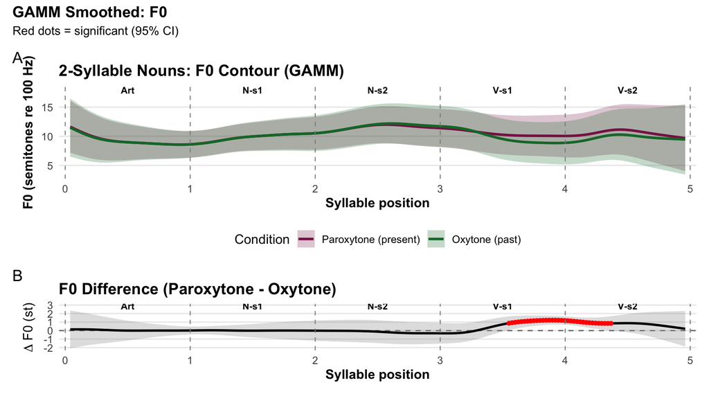

F0 contour (A) and present−past difference (B).

## 2.2 Intensity

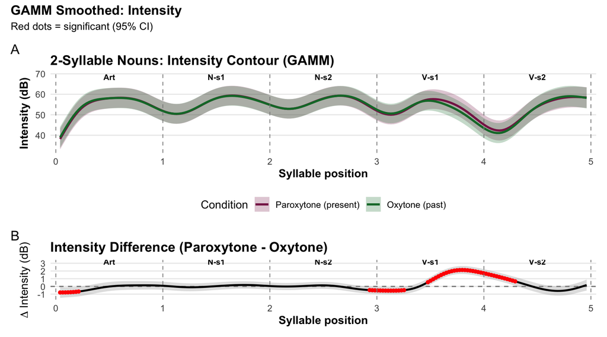

Intensity contour (A) and present−past difference (B). Red points mark the region where the 95% CI excludes zero.

# 3 N-s2 anticipation models (duration, intensity, F0 mean)

**Type.** Parametric (LMM; `lme4::lmer`, ML). Each condition effect assessed by nested model comparison, `anova(restricted, inclusive)` (likelihood-ratio test), reporting df, chi-square, *p*. **DV.** N-s2 duration (ms); mean intensity (dB); mean F0 (st). **IVs (fixed).** `condition`; `order` (covariate). **Random structure.** Maximal `(1 + condition | participant) + (1 + condition | item_id)` attempted, stepping down when singular; structure used is reported per model. Based on 9 participants, 3240 N-s2 tokens.

## 3.1 Duration

Random structure used: (1 + condition │ participant) + (1 │ item_id). N-s2 was shorter before an oxytone verb (b = -10.61 ms; NMC: *χ²*(1) = 19.58, *p* < .001), and remains significant after Bonferroni correction.

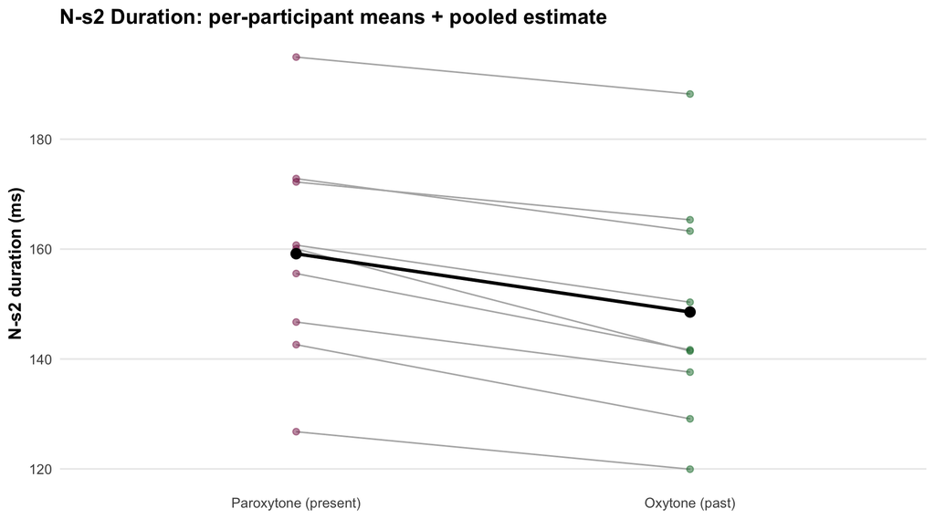

N-s2 duration by condition: each participant’s means (gray) and the population-level pooled estimate (black).

## 3.2 Intensity

Random structure used: (1 + condition │ participant) + (1 │ item_id). No condition difference in N-s2 intensity (b = 0.11 dB; NMC: *χ²*(1) = 0.53, *p* = .468).

# 4 N-s2 F0 contour shape

**Type.** Non-parametric (GAMM; `mgcv::bam`, fREML). Tests whether the F0 trajectory *through* N-s2 differs by condition. **DV.** F0 (st), voiced N-s2 points. **IVs (fixed).** `conditionO` + `s(t)` + `s(t, by = conditionO)`; `order` (covariate); `t` = within-syllable position. **Random intercepts.** by item. **Random slopes.** by-participant reference and difference factor smooths.

The within-syllable F0 tilt differed by condition, s(t):conditionO (*F*(1.00, 1.00) = 30.15, *p* < .001), and remains significant after Bonferroni correction.

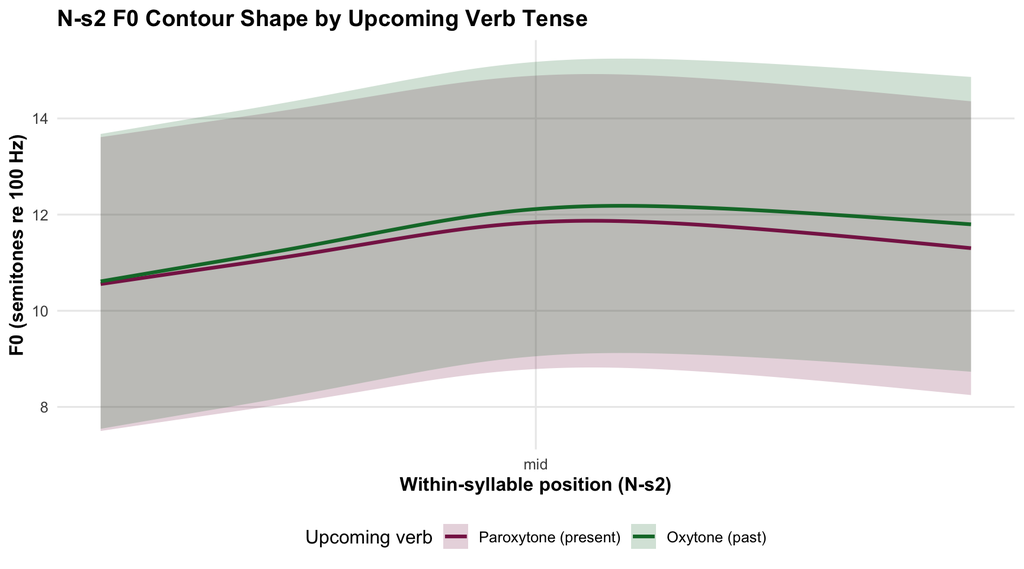

Predicted N-s2 F0 contour by condition.

# 5 Summary of significant findings

[output not shown]

The present/past stress contrast surfaces acoustically at the verb. The noun’s final syllable carries a durational anticipatory cue (shorter before oxytones). Non-significant cues are reported as null above.